# Mesures physiologiques des émotions dans la pratique des jeux vidéos. Expérience AB

Godefroy Clair

16 juillet 2015

subtitle : “Première approche : statistique descriptive”

Travail préliminaire sur les données transmises par Viviane Gal concernant la mesure physiologique d’*un* joueur lors d’*une* expérience. Cette expérience a eu lieu le 6 mars 2014. Les mesures ont été réalisées par 4 capteurs qui concernent respectivement la respiration, l’activité électrodermale, la température et la fréquence cardiaque.

Trois étapes : 1. transformation des données 2. quelques statistiques descriptives 3. Représentations graphiques des données

[output not shown]

### 1. Tranformation des données (nettoyage, mises en forme, décomposition, marquage)

chargement des données au format numérique (sauf 1ère colonne au format “date”, POSIX)

Dimension du tableau de données : 48803 x 6

```
[1] "       date           respiration   activite.electrodermale   temperature   frequence.cardiaque"
[2] "-------------------- ------------  ------------------------  ------------  --------------------"
[3] "2014-03-06 15:19:29       -10.644                   -44.157        29.417                    74"
[4] "2014-03-06 15:19:29       -10.379                   -44.157        29.417                    74"
[5] "2014-03-06 15:19:29       -10.168                   -44.157        29.417                    74"
[6] "2014-03-06 15:19:29        -9.981                   -44.157        29.417                    74"
[7] "2014-03-06 15:19:29        -9.833                   -44.169        29.417                    74"
[8] "2014-03-06 15:19:29        -9.692                   -44.169        29.417                    74"
```

Y a-t-il des données manquantes ?

[1] date respiration activite.electrodermale [4] temperature frequence.cardiaque quart.temps  
<0 rows> (or 0-length row.names)

### 2. statistique descriptive

Quelques statistiques pour résumer les données

|  | date | respiration | activite.electrodermale | temperature | frequence.cardiaque | quart.temps |
| --- | --- | --- | --- | --- | --- | --- |
|  | Min. :2014-03-06 15:19:29 | Min. :-18.670 | Min. :-45.34 | Min. :29.18 | Min. :60.00 | 1er quart :12201 |
|  | 1st Qu.:2014-03-06 15:25:51 | 1st Qu.:-17.859 | 1st Qu.:-44.93 | 1st Qu.:29.99 | 1st Qu.:66.00 | 2eme quart:12201 |
|  | Median :2014-03-06 15:32:12 | Median :-17.500 | Median :-44.73 | Median :31.80 | Median :68.00 | 3eme quart:12200 |
|  | Mean :2014-03-06 15:32:12 | Mean :-16.418 | Mean :-44.31 | Mean :31.55 | Mean :68.09 | 4eme quart:12201 |
|  | 3rd Qu.:2014-03-06 15:38:33 | 3rd Qu.:-15.659 | 3rd Qu.:-44.39 | 3rd Qu.:32.90 | 3rd Qu.:70.00 | NA |
|  | Max. :2014-03-06 15:44:54 | Max. : -8.304 | Max. :-36.30 | Max. :33.18 | Max. :83.00 | NA |

Déviation standard par variable:

```
            respiration activite.electrodermale             temperature
               2.261775                1.440691                1.373293
    frequence.cardiaque
               3.352344
```

### 3. représentations graphiques des données

#### a) Quelques histogrammes

##### Pour l’activité electrodermale :

##### Pour la température :

##### Pour la fréquence cardiaque :

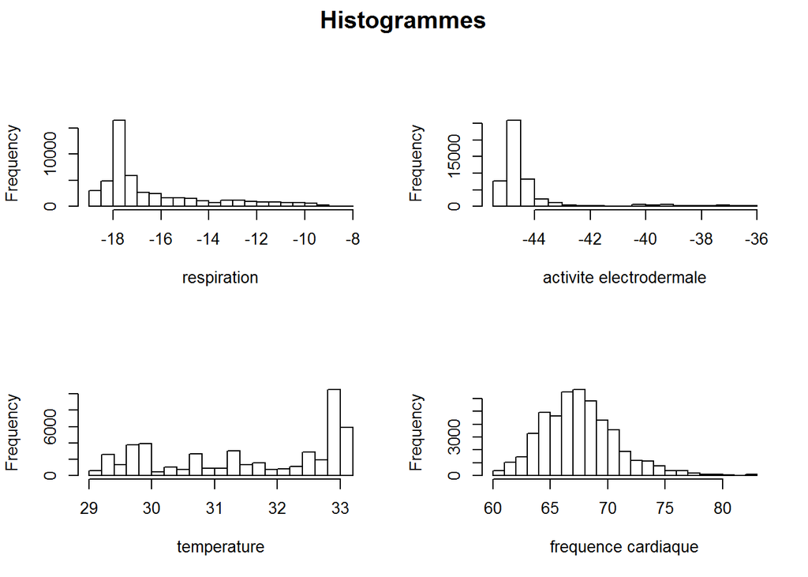

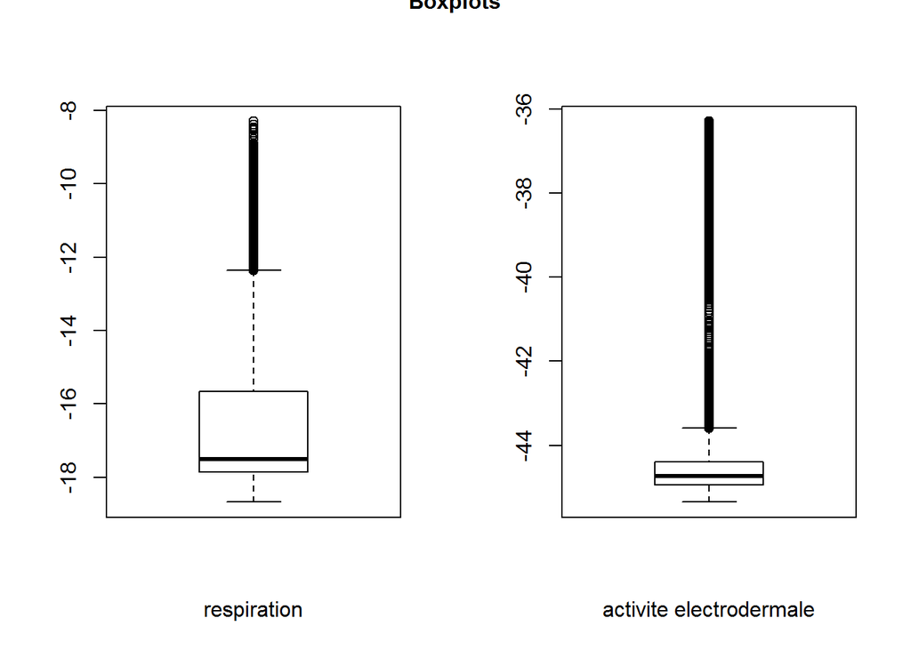

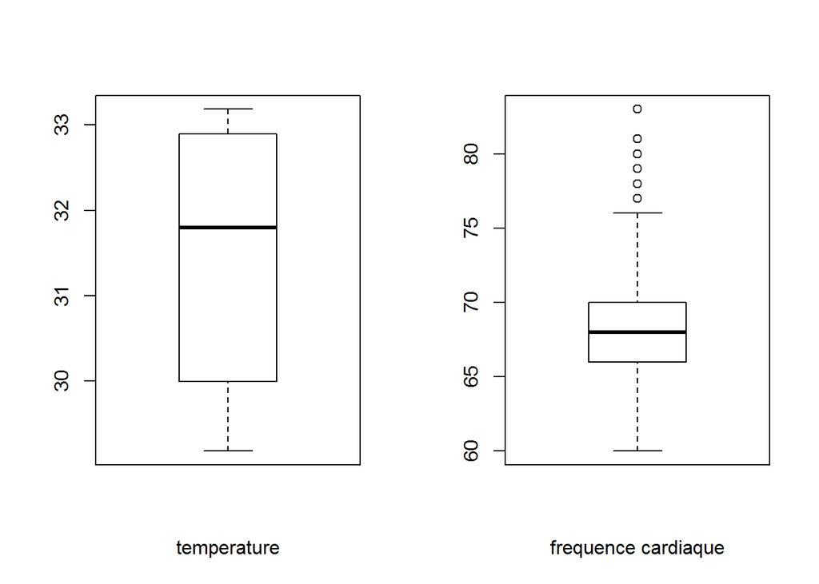

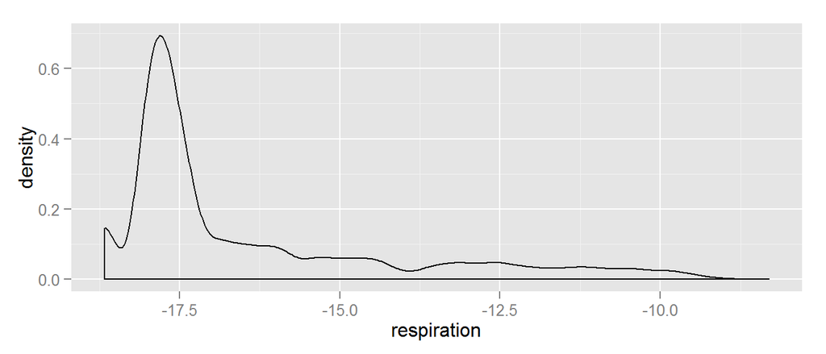

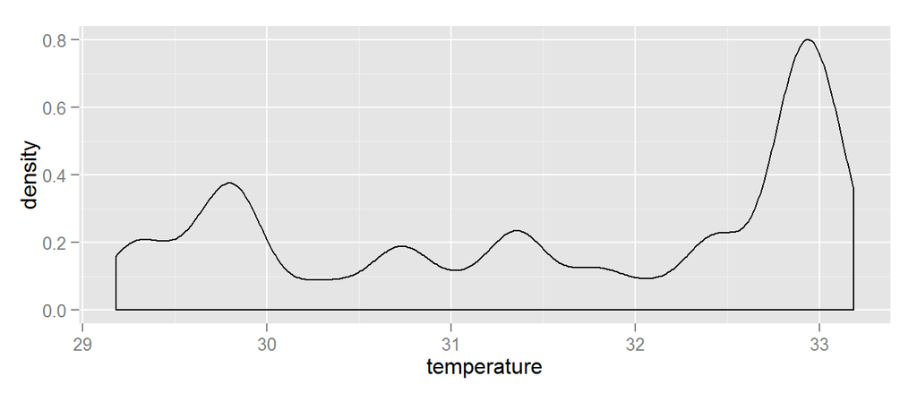

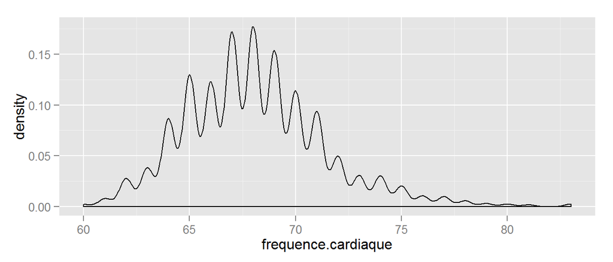

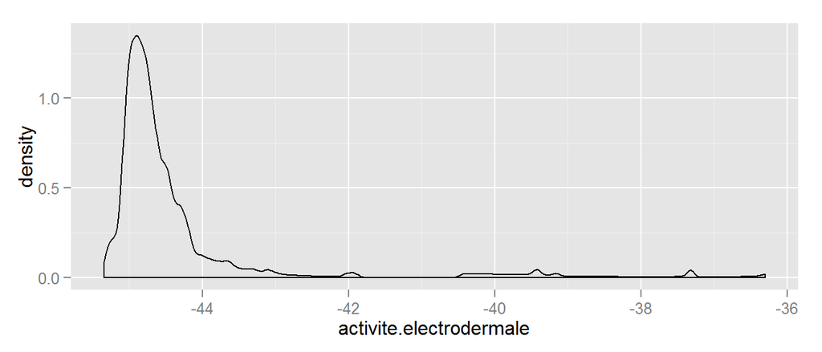

[figure not shown]

frequence respiration, activité ED & séparées par frequence cardiaque :

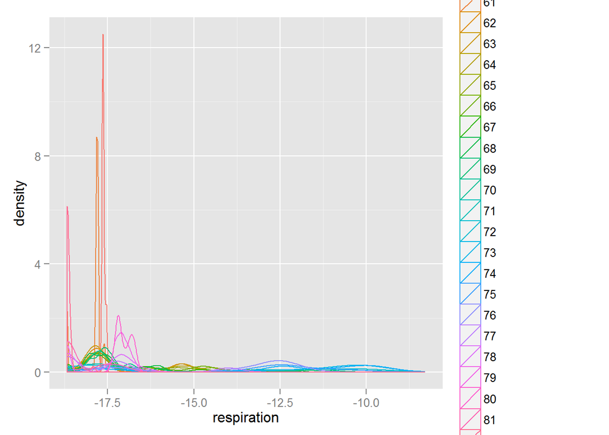

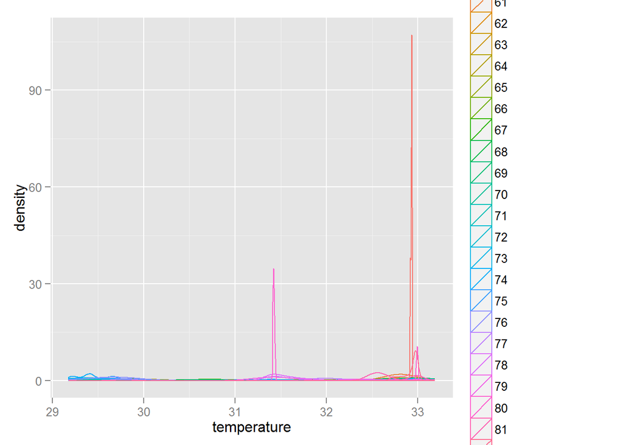

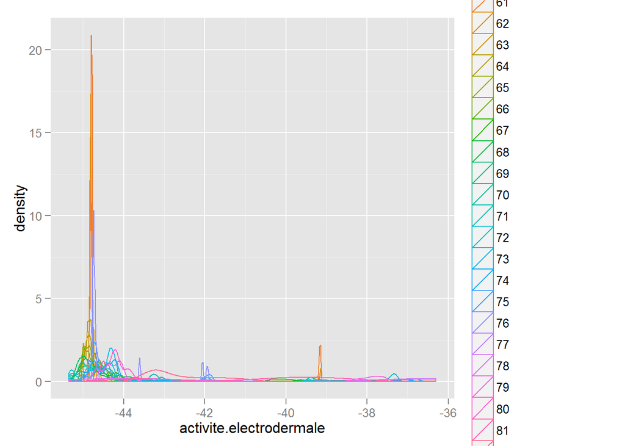

Nuages de points par pair de variables (pour les données de type réels)

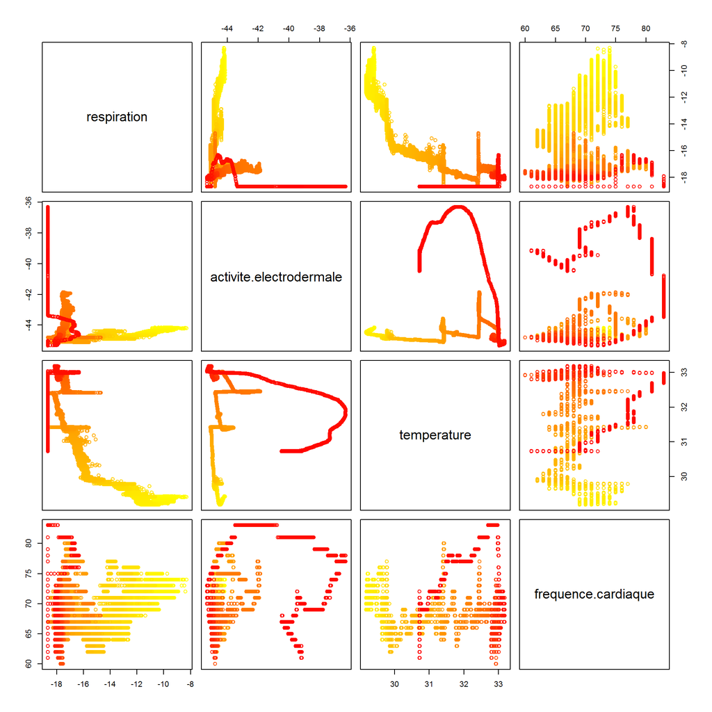

Nuage de points avec variation de l’intensité de la couleur en fonction de la densité:

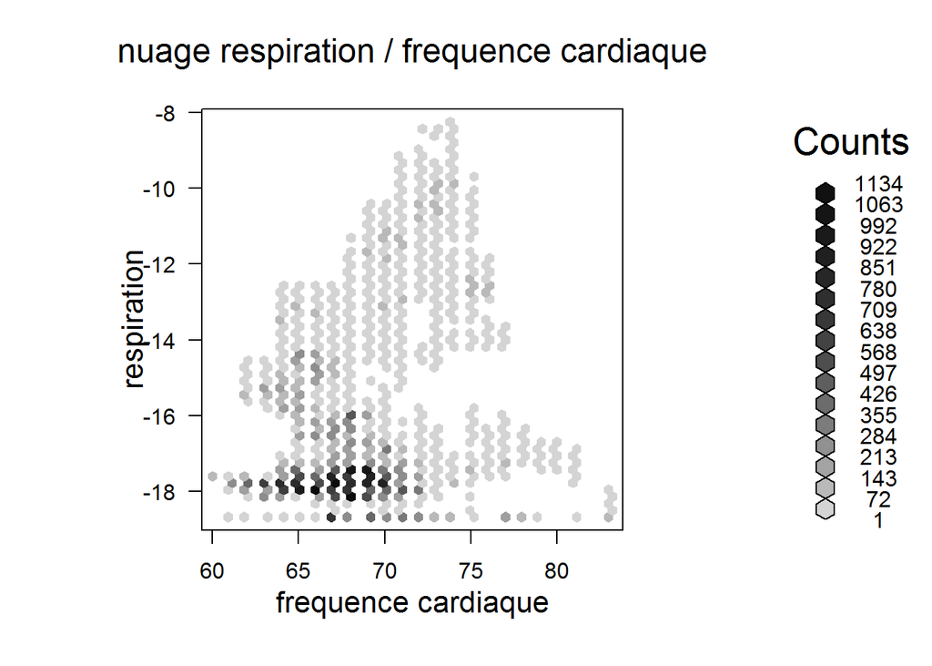

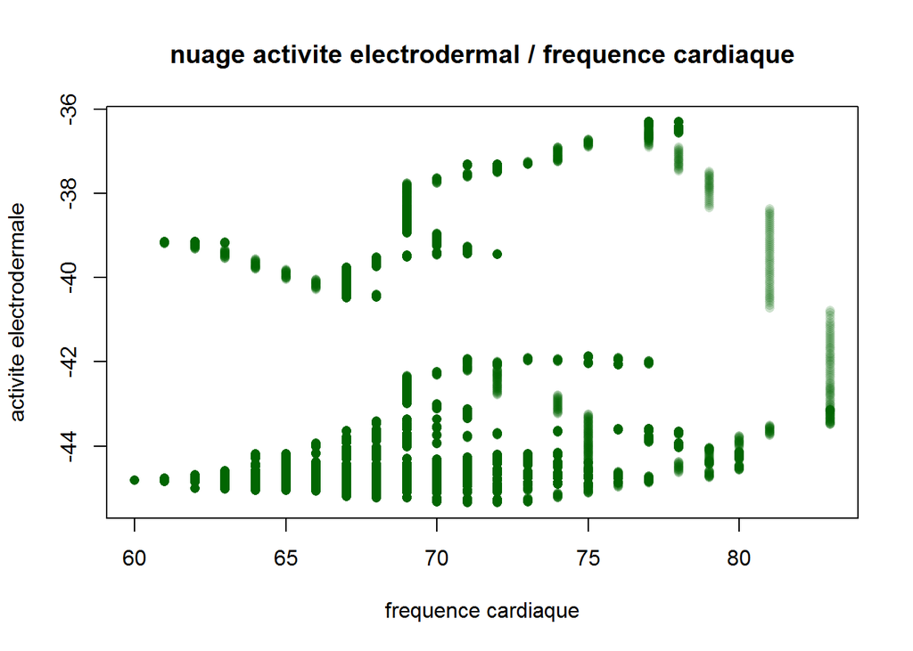

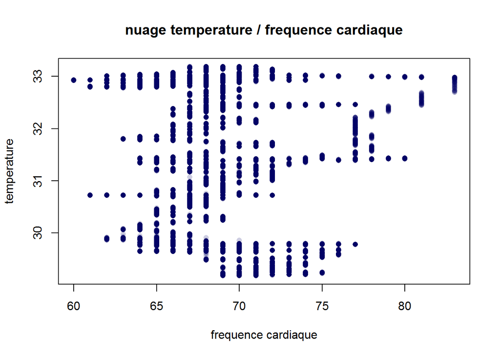

Représentation des données en 3D

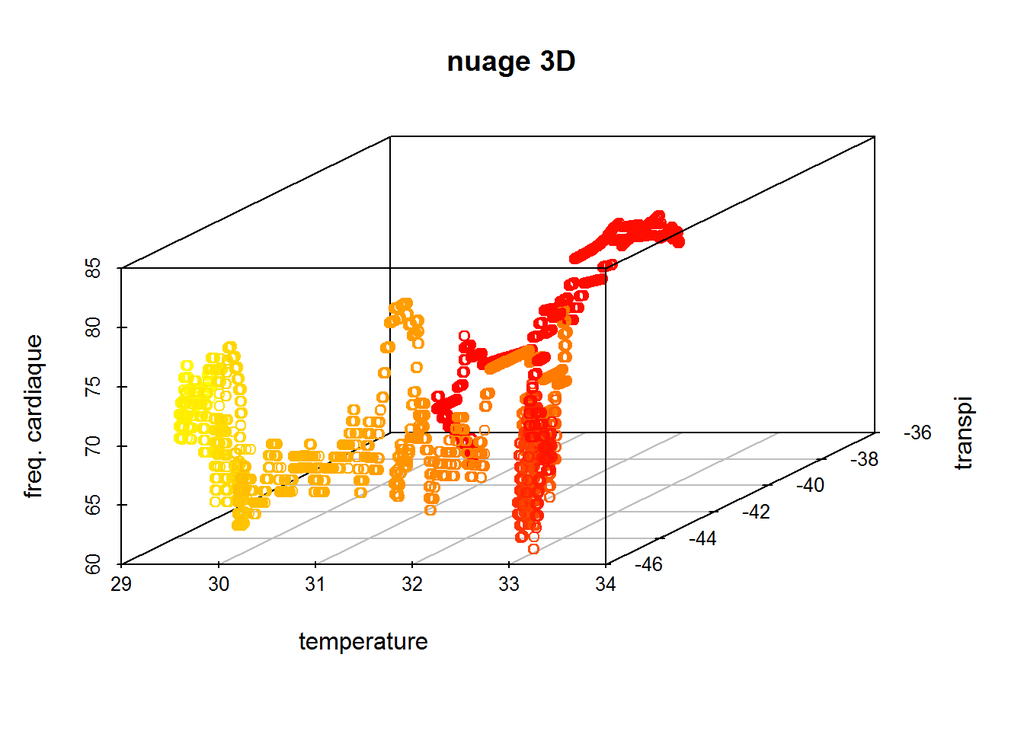

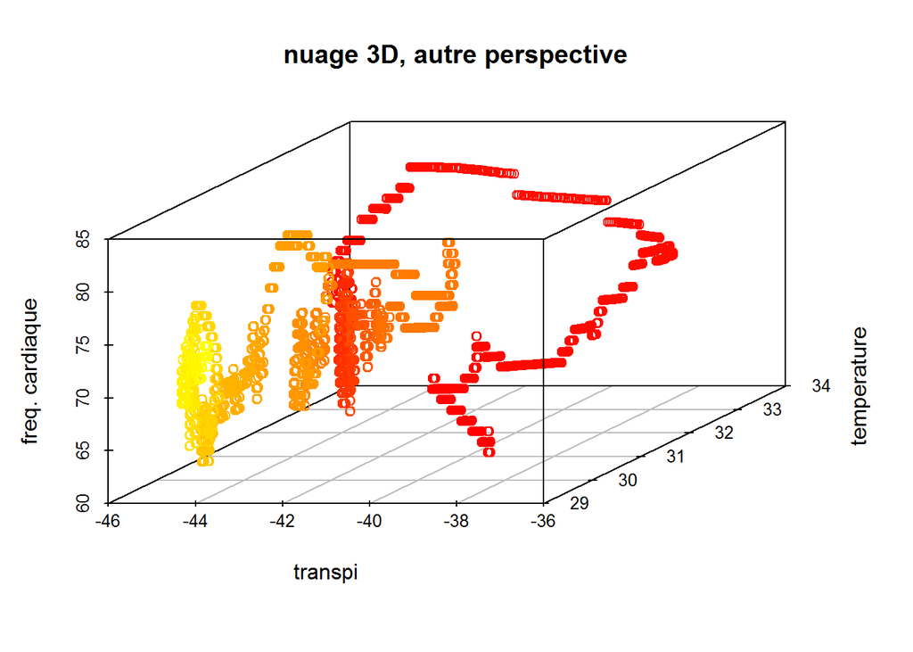

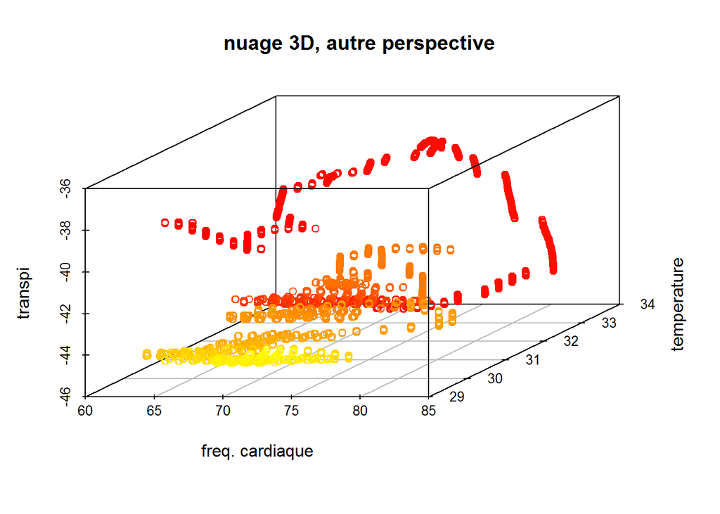

4. Première fouille des données
1. Dendogramme

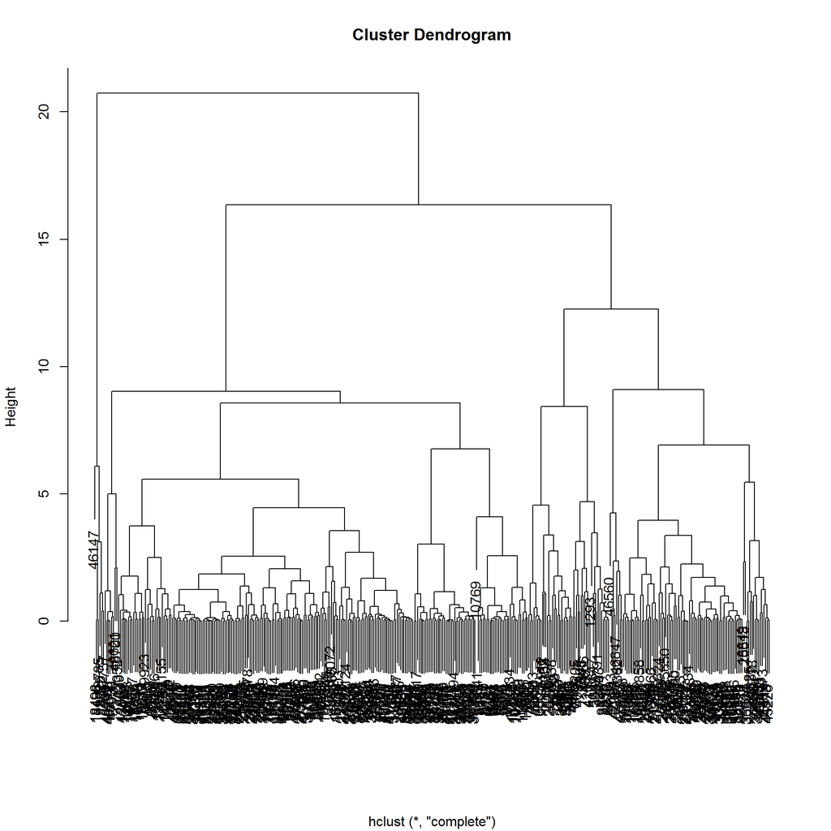

2. SOM (les neurones sont représentés dans l’ordre croissant de leur index de gauche à droite, de bas en haut)

1ère simulation

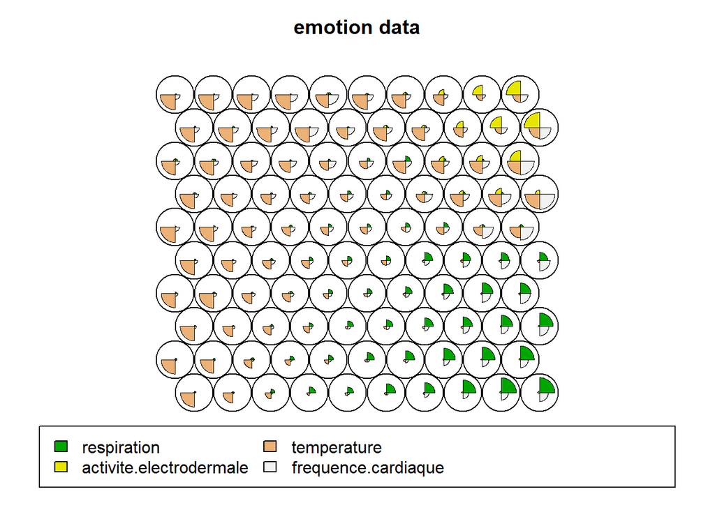

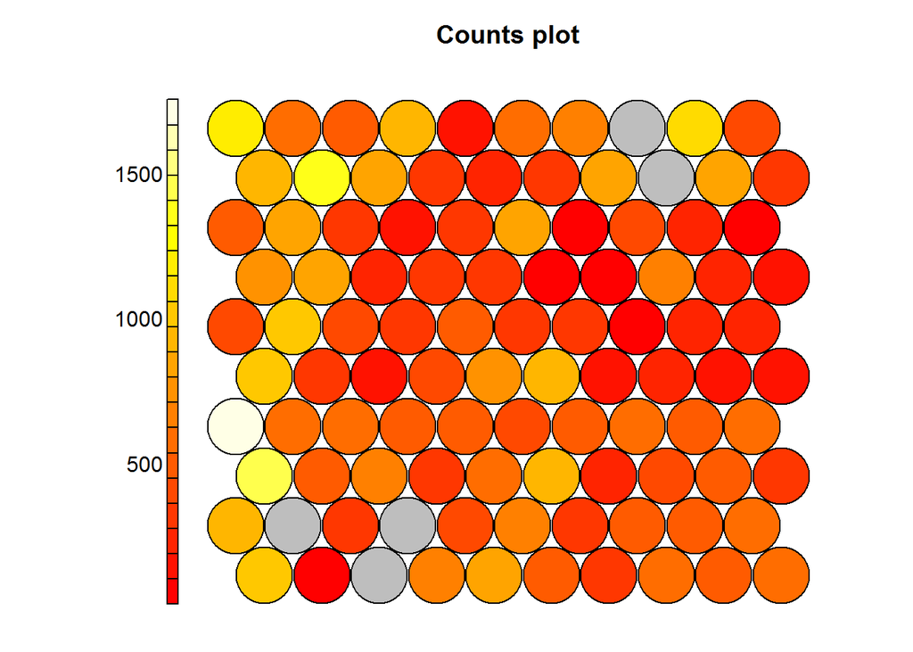

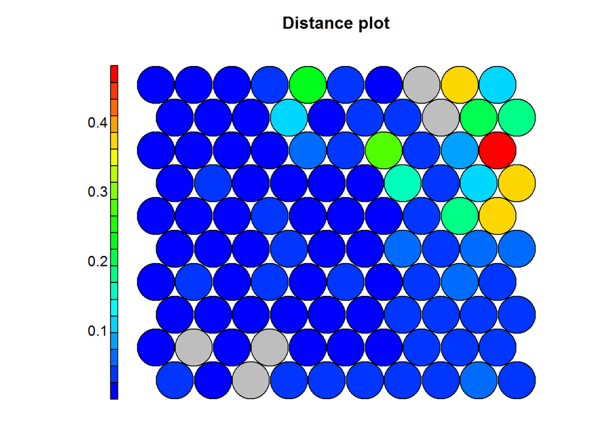

```
##
##    1    2    4    5    6    7    8    9   10   11   13   15   16   17   18
## 1052   60  684  842  486  298  590  459  600  946  316  366  682  327  503
##   19   20   21   22   23   24   25   26   27   28   29   30   31   32   33
##  496  582 1428  466  634  284  606  900  252  384  485  358 1756  555  562
##   34   35   36   37   38   39   40   41   42   43   44   45   46   47   48
##  512  479  413  507  618  475  602 1013  300  136  415  793  890  128  207
##   49   50   51   52   53   54   55   56   57   58   59   60   61   62   63
##  101  133  412 1018  424  284  494  311  304   12  272  216  761  868  252
##   64   65   66   67   68   69   70   71   72   73   74   75   76   77   78
##  356  347   88   86  694  193  114  521  862  280  164  356  839   68  408
##   79   80   81   82   83   84   85   86   87   89   90   91   92   93   94
##  204   63  903 1344  820  342  214  298  798  838  315 1147  574  486  956
##   95   96   97   99  100
##  149  564  632 1073  398
```

2nde simulation

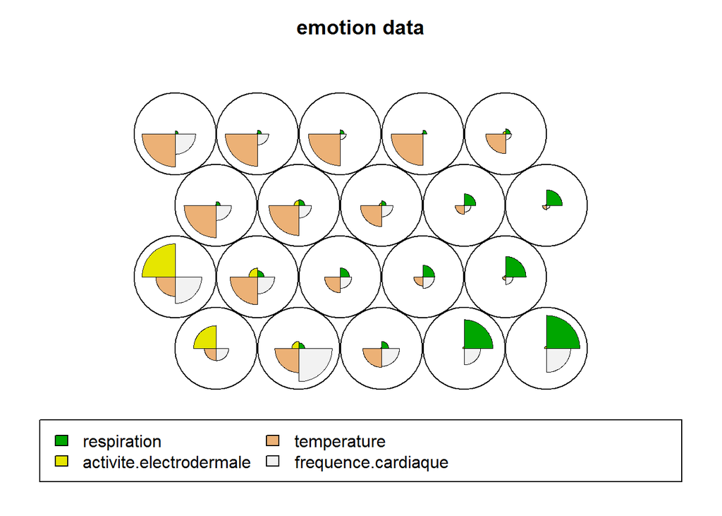

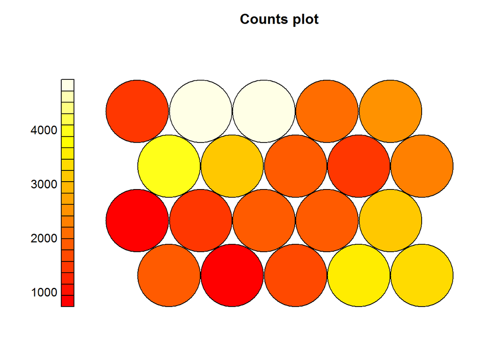

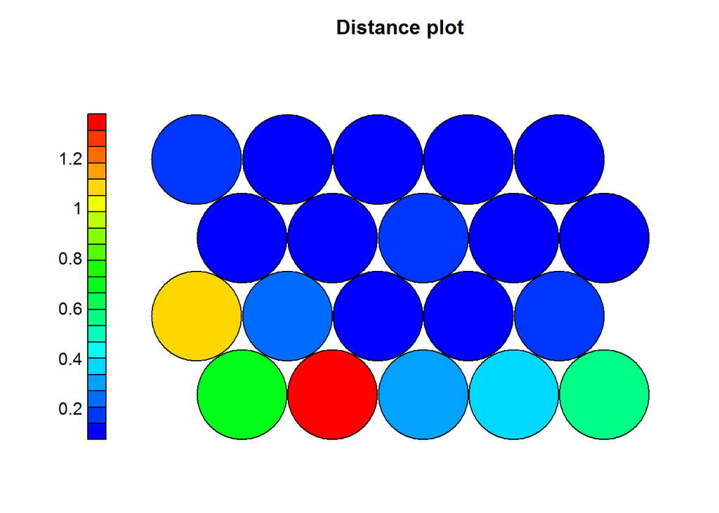

```
##
##    1    2    3    4    5    6    7    8    9   10   11   12   13   14   15
## 1939  836 1621 3470 3427  724 1492 1923 1948 3131 4054 3049 1840 1357 2198
##   16   17   18   19   20
## 1413 4921 4916 1998 2546
```

Regroupement des données

1. par neurone

2. par groupes de neurones